# «Работа с заботой»: Удовлетворенность сотрудников и их отток

HR-аналитики компании «Работа с заботой» помогают бизнесу оптимизировать управление персоналом: бизнес предоставляет данные, а аналитики предлагают, как избежать финансовых потерь и оттока сотрудников. В этом HR-аналитикам пригодится машинное обучение, с помощью которого получится быстрее и точнее отвечать на вопросы бизнеса.

Компания предоставила данные с характеристиками сотрудников компании. Среди них — уровень удовлетворённости сотрудника работой в компании. Эту информацию получили из форм обратной связи: сотрудники заполняют тест-опросник, и по его результатам рассчитывается доля их удовлетворённости от 0 до 1, где 0 — совершенно неудовлетворён, 1 — полностью удовлетворён.

Удовлетворённость работой напрямую влияет на отток сотрудников. Предсказание оттока — одна из важнейших задач HR-аналитиков. Внезапные увольнения несут в себе риски для компании, особенно если уходит важный сотрудник. Вторая задача — построить модель, которая сможет на основе данных заказчика предсказать то, что сотрудник уволится из компании.

Ход работы:

- Импорт библиотек
- Вспомогательные функции
- Предсказание удовлетворённости
  - Описание данных
  - Загрузка данных
  - Исследовательский анализ данных
    - Общий обзор
    - Выбросы
    - Неявные дубли
  - Корреляционный анализ
  - Моделирование
    - Подготовка данных
    - Поиск модели и обработки
    - Лучшая модель
    - Сравнение разных моделей
- Предсказание увольнения
  - Загрузка данных
  - Исследовательский анализ данных
    - Общий обзор
    - Выбросы
    - Неявные дубли
  - Корреляционный анализ
  - Портрет уволившегося сотрудника
  - Промежуточный вывод
- Моделирование
  - Подготовка данных
  - Поиск модели и обработки
  - Предсказание увольнения
  - Сравнение разных моделей
- Общий вывод

## Импорт библиотек

```python
import pandas as pd
import numpy as np
import matplotlib.pyplot as plt
import seaborn as sns
from scipy import stats
import tqdm as notebook_tqdm

from sklearn.dummy import DummyRegressor, DummyClassifier
from sklearn.model_selection import GridSearchCV
from sklearn.preprocessing import (
    StandardScaler,
    MinMaxScaler,
    RobustScaler,
    OneHotEncoder,
    OrdinalEncoder,
    LabelEncoder,
)
from sklearn.impute import SimpleImputer
from sklearn.linear_model import LogisticRegression, LinearRegression
from sklearn.neighbors import KNeighborsClassifier, KNeighborsRegressor
from sklearn.tree import DecisionTreeClassifier, DecisionTreeRegressor
from sklearn.svm import SVC, SVR
from sklearn.pipeline import Pipeline
from sklearn.compose import ColumnTransformer
from sklearn.metrics import roc_auc_score, make_scorer

sns.set(rc={'figure.figsize': (20, 10)})

RANDOM_STATE = 42
TEST_SIZE = 0.25
```

## Вспомогательные функции

```python
def plot_train_test(
    train,
    test,
    variable,
    title,
    ylabel,
    norm=False,
    left_title='Train',
    right_title='Test',
    xlabel='Количество пользователей',
):
    '''Рисует горизонтальные барплоты для тренировочной и тестовой выборок'''
    f, (ax1, ax2) = plt.subplots(1, 2, figsize=(20, 5))
    f.suptitle(title, fontsize=20)

    f.text(0.5, 0.04, xlabel, ha='center')

    (
        train[variable]
        .value_counts(normalize=norm)
        .sort_values()
        .plot.barh(figsize=(20, 5), color='green', label='test', ax=ax1)
    )
    ax1.set_title(left_title)
    ax1.set_ylabel(ylabel)

    (
        test[variable]
        .value_counts(normalize=norm)
        .sort_values()
        .plot.barh(figsize=(20, 5), color='blue', label='train', ax=ax2)
    )
    ax2.set_title(right_title)

    plt.show()
```

```python
def transform_columns_values(df):
    '''
    Функция приводит значения колонок и значений к единому формату
    Заменяет пробелы на _, приводит к нижнему регистру
    '''
    df.columns = df.columns.str.replace(' ', '_', regex=True).str.lower()
    object_columns = df.select_dtypes('object').columns
    df[object_columns] = df.select_dtypes('object').apply(
        lambda x: x.str.replace(' ', '_', regex=True).str.lower()
    )
    display(df.info())
    print('\n')
    display(df.describe())
    display(df.head())
    print(f'''Явных дублей: {df.duplicated().sum()}\n\n''')
    print('Пропущенных значений:\n')
    display(
        (
            pd.DataFrame(
                round(df.isna().mean() * 100, 1).sort_values(ascending=False)
            ).style.background_gradient('coolwarm')
        )
    )
    return df
```

## Предсказание удовлетворённости

### Описание данных:

*id* — уникальный идентификатор сотрудника;  
*dept* — отдел, в котором работает сотрудник;  
*level* — уровень занимаемой должности;  
*workload* — уровень загруженности сотрудника;  
*employment_years* — длительность работы в компании (в годах);  
*last_year_promo* — показывает, было ли повышение за последний год;  
*last_year_violations* — показывает, нарушал ли сотрудник трудовой договор за последний год;  
*supervisor_evaluation* — оценка качества работы сотрудника, которую дал руководитель;  
*salary* — ежемесячная зарплата сотрудника;  
*job_satisfaction_rate* — уровень удовлетворённости сотрудника работой в компании, целевой признак.

### Загрузка данных

```python
train = pd.read_csv('/datasets/train_job_satisfaction_rate.csv')
X_test = pd.read_csv('/datasets/test_features.csv')
y_test = pd.read_csv('/datasets/test_target_job_satisfaction_rate.csv')
```

### Исследовательский анализ данных

#### Общий обзор

```python
for df in [train, X_test, y_test]:
    df = transform_columns_values(df)
```

```
<class 'pandas.core.frame.DataFrame'>
RangeIndex: 4000 entries, 0 to 3999
Data columns (total 10 columns):
 #   Column                 Non-Null Count  Dtype
---  ------                 --------------  -----
 0   id                     4000 non-null   int64
 1   dept                   3994 non-null   object
 2   level                  3996 non-null   object
 3   workload               4000 non-null   object
 4   employment_years       4000 non-null   int64
 5   last_year_promo        4000 non-null   object
 6   last_year_violations   4000 non-null   object
 7   supervisor_evaluation  4000 non-null   int64
 8   salary                 4000 non-null   int64
 9   job_satisfaction_rate  4000 non-null   float64
dtypes: float64(1), int64(4), object(5)
memory usage: 312.6+ KB
```

```
None
```

|  | id | employment_years | supervisor_evaluation | salary | job_satisfaction_rate |
| --- | --- | --- | --- | --- | --- |
| count | 4000.000000 | 4000.000000 | 4000.000000 | 4000.000000 | 4000.000000 |
| mean | 544957.621000 | 3.718500 | 3.476500 | 33926.700000 | 0.533995 |
| std | 257883.104622 | 2.542513 | 1.008812 | 14900.703838 | 0.225327 |
| min | 100954.000000 | 1.000000 | 1.000000 | 12000.000000 | 0.030000 |
| 25% | 322836.750000 | 2.000000 | 3.000000 | 22800.000000 | 0.360000 |
| 50% | 534082.500000 | 3.000000 | 4.000000 | 30000.000000 | 0.560000 |
| 75% | 771446.000000 | 6.000000 | 4.000000 | 43200.000000 | 0.710000 |
| max | 999521.000000 | 10.000000 | 5.000000 | 98400.000000 | 1.000000 |

|  | id | dept | level | workload | employment_years | last_year_promo | last_year_violations | supervisor_evaluation | salary | job_satisfaction_rate |
| --- | --- | --- | --- | --- | --- | --- | --- | --- | --- | --- |
| 0 | 155278 | sales | junior | medium | 2 | no | no | 1 | 24000 | 0.58 |
| 1 | 653870 | hr | junior | high | 2 | no | no | 5 | 38400 | 0.76 |
| 2 | 184592 | sales | junior | low | 1 | no | no | 2 | 12000 | 0.11 |
| 3 | 171431 | technology | junior | low | 4 | no | no | 2 | 18000 | 0.37 |
| 4 | 693419 | hr | junior | medium | 1 | no | no | 3 | 22800 | 0.20 |

```
Явных дублей: 0


Пропущенных значений:
```

|  | 0 |
| --- | --- |
| dept | 0.200000 |
| level | 0.100000 |
| id | 0.000000 |
| workload | 0.000000 |
| employment_years | 0.000000 |
| last_year_promo | 0.000000 |
| last_year_violations | 0.000000 |
| supervisor_evaluation | 0.000000 |
| salary | 0.000000 |
| job_satisfaction_rate | 0.000000 |

```
<class 'pandas.core.frame.DataFrame'>
RangeIndex: 2000 entries, 0 to 1999
Data columns (total 9 columns):
 #   Column                 Non-Null Count  Dtype
---  ------                 --------------  -----
 0   id                     2000 non-null   int64
 1   dept                   1998 non-null   object
 2   level                  1999 non-null   object
 3   workload               2000 non-null   object
 4   employment_years       2000 non-null   int64
 5   last_year_promo        2000 non-null   object
 6   last_year_violations   2000 non-null   object
 7   supervisor_evaluation  2000 non-null   int64
 8   salary                 2000 non-null   int64
dtypes: int64(4), object(5)
memory usage: 140.8+ KB
```

```
None
```

|  | id | employment_years | supervisor_evaluation | salary |
| --- | --- | --- | --- | --- |
| count | 2000.000000 | 2000.000000 | 2000.000000 | 2000.000000 |
| mean | 552765.213500 | 3.666500 | 3.526500 | 34066.800000 |
| std | 253851.326129 | 2.537222 | 0.996892 | 15398.436729 |
| min | 100298.000000 | 1.000000 | 1.000000 | 12000.000000 |
| 25% | 339052.000000 | 1.000000 | 3.000000 | 22800.000000 |
| 50% | 550793.000000 | 3.000000 | 4.000000 | 30000.000000 |
| 75% | 765763.750000 | 6.000000 | 4.000000 | 43200.000000 |
| max | 999029.000000 | 10.000000 | 5.000000 | 96000.000000 |

|  | id | dept | level | workload | employment_years | last_year_promo | last_year_violations | supervisor_evaluation | salary |
| --- | --- | --- | --- | --- | --- | --- | --- | --- | --- |
| 0 | 485046 | marketing | junior | medium | 2 | no | no | 5 | 28800 |
| 1 | 686555 | hr | junior | medium | 1 | no | no | 4 | 30000 |
| 2 | 467458 | sales | middle | low | 5 | no | no | 4 | 19200 |
| 3 | 418655 | sales | middle | low | 6 | no | no | 4 | 19200 |
| 4 | 789145 | hr | middle | medium | 5 | no | no | 5 | 40800 |

```
Явных дублей: 0


Пропущенных значений:
```

|  | 0 |
| --- | --- |
| dept | 0.100000 |
| id | 0.000000 |
| level | 0.000000 |
| workload | 0.000000 |
| employment_years | 0.000000 |
| last_year_promo | 0.000000 |
| last_year_violations | 0.000000 |
| supervisor_evaluation | 0.000000 |
| salary | 0.000000 |

```
<class 'pandas.core.frame.DataFrame'>
RangeIndex: 2000 entries, 0 to 1999
Data columns (total 2 columns):
 #   Column                 Non-Null Count  Dtype
---  ------                 --------------  -----
 0   id                     2000 non-null   int64
 1   job_satisfaction_rate  2000 non-null   float64
dtypes: float64(1), int64(1)
memory usage: 31.4 KB
```

```
None
```

|  | id | job_satisfaction_rate |
| --- | --- | --- |
| count | 2000.000000 | 2000.00000 |
| mean | 552765.213500 | 0.54878 |
| std | 253851.326129 | 0.22011 |
| min | 100298.000000 | 0.03000 |
| 25% | 339052.000000 | 0.38000 |
| 50% | 550793.000000 | 0.58000 |
| 75% | 765763.750000 | 0.72000 |
| max | 999029.000000 | 1.00000 |

|  | id | job_satisfaction_rate |
| --- | --- | --- |
| 0 | 130604 | 0.74 |
| 1 | 825977 | 0.75 |
| 2 | 418490 | 0.60 |
| 3 | 555320 | 0.72 |
| 4 | 826430 | 0.08 |

```
Явных дублей: 0


Пропущенных значений:
```

|  | 0 |
| --- | --- |
| id | 0.000000 |
| job_satisfaction_rate | 0.000000 |

Пропущенные значения мы обработаем на этапе подготовки данных.

#### Выбросы

Проверим непрерывные переменные на предмет выбросов с помощью вычисления z-значения.

```python
# Аномальные зарплаты в тренировочной выборке
anomal_salary = train[np.abs(stats.zscore(train['salary'])) >= 3]
print(f'''Аномальных зарплат: {len(anomal_salary)}''')
anomal_salary.head()
```

```
Аномальных зарплат: 40
```

|  | id | dept | level | workload | employment_years | last_year_promo | last_year_violations | supervisor_evaluation | salary | job_satisfaction_rate |
| --- | --- | --- | --- | --- | --- | --- | --- | --- | --- | --- |
| 45 | 538347 | technology | sinior | high | 3 | no | no | 1 | 84000 | 0.21 |
| 141 | 128304 | marketing | sinior | high | 7 | no | no | 3 | 80400 | 0.48 |
| 360 | 405345 | marketing | sinior | high | 7 | no | no | 2 | 81600 | 0.58 |
| 1203 | 493024 | technology | sinior | high | 10 | no | no | 4 | 79200 | 0.64 |
| 1241 | 148024 | technology | sinior | high | 4 | no | no | 4 | 94800 | 0.67 |

```python
anomal_salary[['level', 'dept']].value_counts()
```

```
level   dept
sinior  technology    17
        marketing      8
        purchasing     7
        hr             5
        sales          3
dtype: int64
```

```python
# Аномальные зарплаты в тестовой выборке
anomal_salary = X_test[np.abs(stats.zscore(X_test['salary'])) >= 3]
print(f'''Аномальных зарплат: {len(anomal_salary)}''')
anomal_salary.head()
```

```
Аномальных зарплат: 23
```

|  | id | dept | level | workload | employment_years | last_year_promo | last_year_violations | supervisor_evaluation | salary |
| --- | --- | --- | --- | --- | --- | --- | --- | --- | --- |
| 178 | 540148 | hr | sinior | high | 4 | no | no | 5 | 81600 |
| 438 | 270400 | technology | sinior | high | 2 | no | no | 4 | 94800 |
| 459 | 719982 | marketing | sinior | high | 9 | no | no | 5 | 82800 |
| 594 | 950627 | technology | sinior | high | 6 | no | no | 5 | 80400 |
| 698 | 145965 | technology | sinior | high | 1 | no | no | 4 | 87600 |

```python
anomal_salary[['level', 'dept']].value_counts()
```

```
level   dept
sinior  technology    16
        hr             3
        marketing      2
        purchasing     1
        sales          1
dtype: int64
```

Нетипичные зарплаты имеют старшие специалисты всех отделов. Их не очень много по сравнению с младшими и средними, поэтому считаем, что это нормально. В тестовой выборке они тоже присутствуют, важно уметь их предсказывать.

#### Неявные дубли

Наличие одинаковых строк в таблице может затруднить обучение модели. Вынесем `id` в индекс и проверим, есть ли такие.

```python
train = train.set_index('id')
X_test = X_test.set_index('id')
y_test = y_test.set_index('id')
train.head()
```

| id | dept | level | workload | employment_years | last_year_promo | last_year_violations | supervisor_evaluation | salary | job_satisfaction_rate |
| --- | --- | --- | --- | --- | --- | --- | --- | --- | --- |
| 155278 | sales | junior | medium | 2 | no | no | 1 | 24000 | 0.58 |
| 653870 | hr | junior | high | 2 | no | no | 5 | 38400 | 0.76 |
| 184592 | sales | junior | low | 1 | no | no | 2 | 12000 | 0.11 |
| 171431 | technology | junior | low | 4 | no | no | 2 | 18000 | 0.37 |
| 693419 | hr | junior | medium | 1 | no | no | 3 | 22800 | 0.20 |

```python
train[train.duplicated(keep=False)].sort_values(
    ['dept', 'level', 'employment_years']
).tail(4)
```

| id | dept | level | workload | employment_years | last_year_promo | last_year_violations | supervisor_evaluation | salary | job_satisfaction_rate |
| --- | --- | --- | --- | --- | --- | --- | --- | --- | --- |
| 850573 | technology | middle | medium | 5 | no | no | 4 | 40800 | 0.65 |
| 717020 | technology | middle | medium | 5 | no | no | 4 | 40800 | 0.65 |
| 928326 | technology | middle | medium | 7 | no | no | 3 | 38400 | 0.40 |
| 516194 | technology | middle | medium | 7 | no | no | 3 | 38400 | 0.40 |

После выноса `id` в индекс, появились дубликаты, которые могут затруднить обучение модели. Избавимся от них.

```python
train = train.drop_duplicates()
```

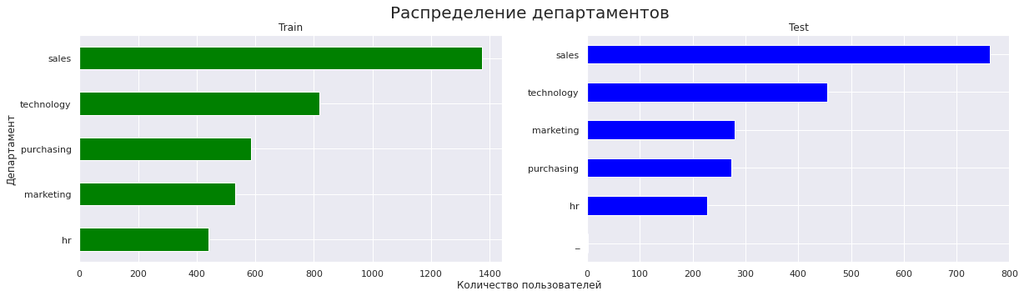

```python
plot_train_test(
    train, X_test, 'dept', 'Распределение департаментов', 'Департамент'
)
```

Видно, что структура в целом очень похожа. В тестовом датасете есть ошибочные записи, в них отдел указан как '_'. Заполним их пустыми значениями.

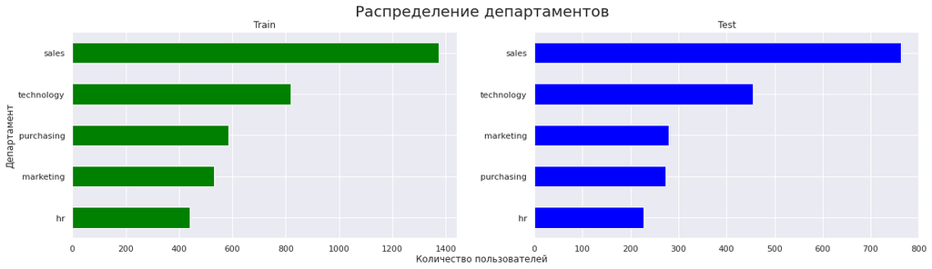

```python
X_test['dept'] = X_test['dept'].replace('_', np.nan)
plot_train_test(
    train, X_test, 'dept', 'Распределение департаментов', 'Департамент'
)
```

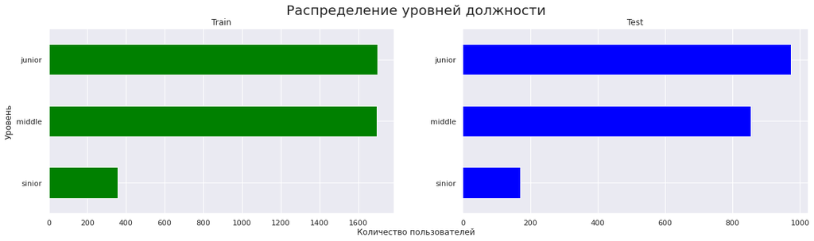

```python
plot_train_test(
    train, X_test, 'level', 'Распределение уровней должности', 'Уровень'
)
```

Старших специалистов сильно меньше, чем остальных. Так обычно и бывает. Структуры тренировочной и тестовой выборок похожи.

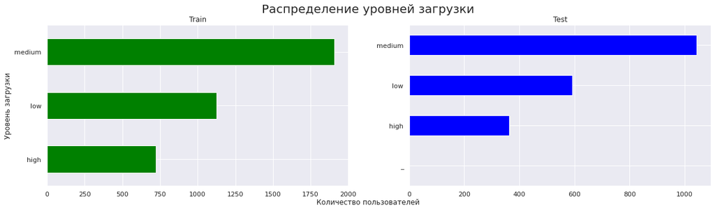

```python
plot_train_test(
    train,
    X_test,
    'workload',
    'Распределение уровней загрузки',
    'Уровень загрузки',
)
```

Высоконагруженных специалистов меньше всего - это должно хорошо сказываться на общей удовлетворенности. Снова видно записи с ошибкой в тестовой выборке. Заполним пустыми значениями.

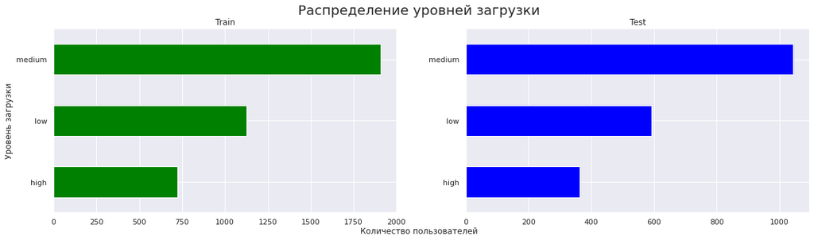

```python
X_test['workload'] = X_test['workload'].replace('_', np.nan)
plot_train_test(
    train,
    X_test,
    'workload',
    'Распределение уровней загрузки',
    'Уровень загрузки',
)
```

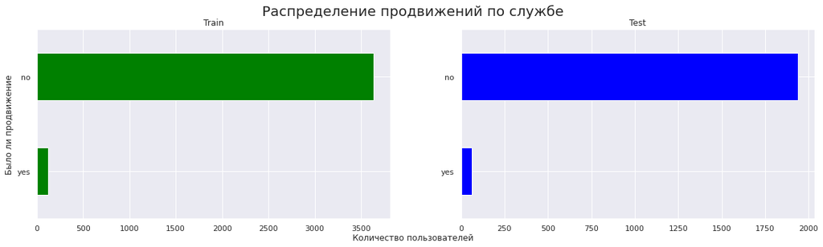

```python
plot_train_test(
    train,
    X_test,
    'last_year_promo',
    'Распределение продвижений по службе',
    'Было ли продвижение',
)
```

Не так много сотрудников продвигаются по службе. Такой дисбаланс может сказаться на качестве модели. Нужно будет его устранить.

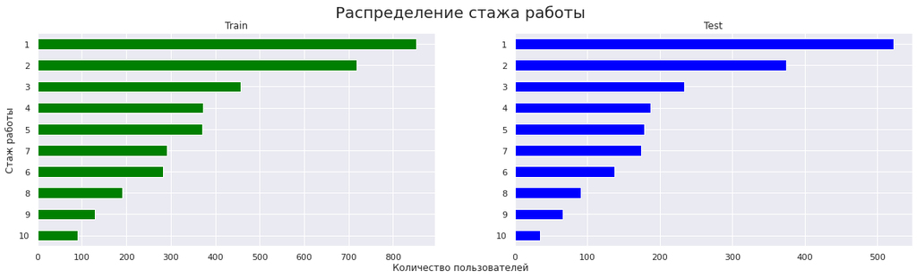

```python
plot_train_test(
    train,
    X_test,
    'employment_years',
    'Распределение стажа работы',
    'Стаж работы',
)
```

В компании много новичков. Чем дальше, тем меньше сотрудников. Это нормально для нашего времени.

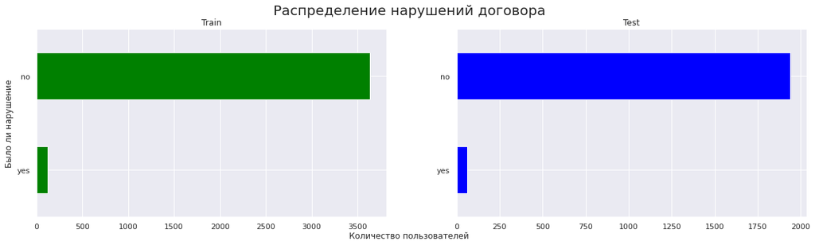

```python
plot_train_test(
    train,
    X_test,
    'last_year_promo',
    'Распределение нарушений договора',
    'Было ли нарушение',
)
```

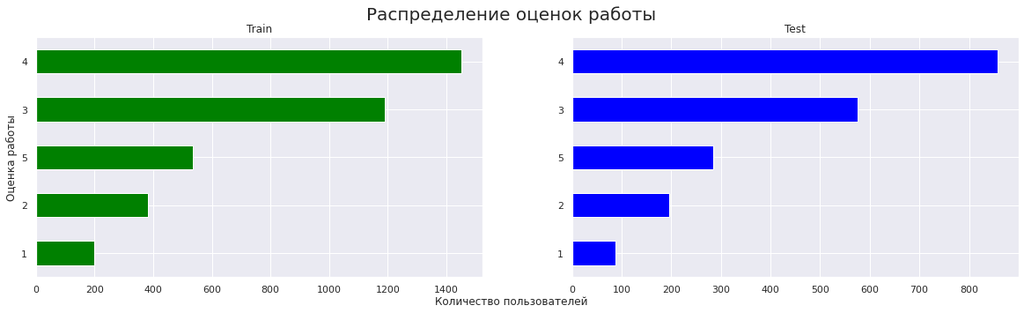

```python
plot_train_test(
    train,
    X_test,
    'supervisor_evaluation',
    'Распределение оценок работы',
    'Оценка работы',
)
```

Преобладают средние и высокие оценки.

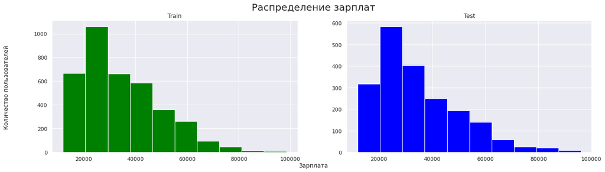

```python
f, (ax1, ax2) = plt.subplots(1, 2, figsize=(20, 5))
f.suptitle('Распределение зарплат', fontsize=20)

f.text(0.5, 0.04, 'Зарплата', ha='center')
f.text(
    0.06,
    0.5,
    'Количество пользователей',
    ha='center',
    va='center',
    rotation='vertical',
)

train['salary'].hist(figsize=(20, 5), color='green', ax=ax1)
ax1.set_title('Train')

X_test['salary'].hist(figsize=(20, 5), color='blue', ax=ax2)
ax2.set_title('Test')

plt.show()
```

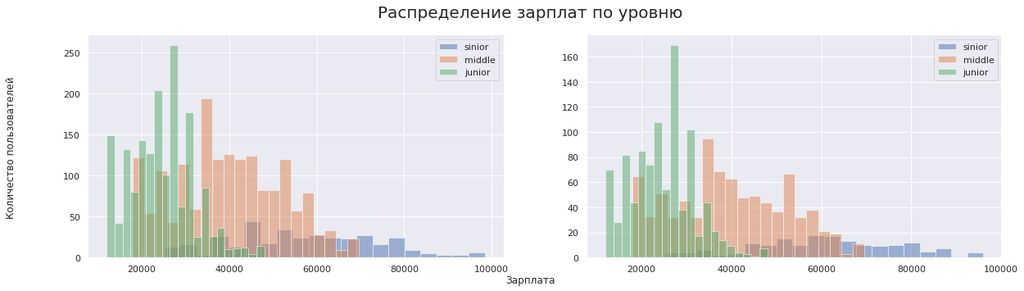

```python
f, (ax1, ax2) = plt.subplots(1, 2, figsize=(20, 5))
f.suptitle('Распределение зарплат по уровню', fontsize=20)

f.text(0.5, 0.04, 'Зарплата', ha='center')
f.text(
    0.06,
    0.5,
    'Количество пользователей',
    ha='center',
    va='center',
    rotation='vertical',
)

ax1.hist(
    train.query('level == "sinior"')['salary'],
    bins=20,
    alpha=0.5,
    label='sinior',
)
ax1.hist(
    train.query('level == "middle"')['salary'],
    bins=20,
    alpha=0.5,
    label='middle',
)
ax1.hist(
    train.query('level == "junior"')['salary'],
    bins=20,
    alpha=0.5,
    label='junior',
)
ax1.legend()

ax2.hist(
    X_test.query('level == "sinior"')['salary'],
    bins=20,
    alpha=0.5,
    label='sinior',
)
ax2.hist(
    X_test.query('level == "middle"')['salary'],
    bins=20,
    alpha=0.5,
    label='middle',
)
ax2.hist(
    X_test.query('level == "junior"')['salary'],
    bins=20,
    alpha=0.5,
    label='junior',
)
ax2.legend()

plt.show()
```

Зарплата также зависит от отдела, в том числе и поэтому часть старших специалистом одного отдела получают зарплату младших специалистов другого.

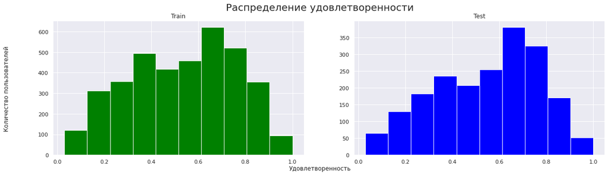

```python
f, (ax1, ax2) = plt.subplots(1, 2, figsize=(20, 5))
f.suptitle('Распределение удовлетворенности', fontsize=20)

f.text(0.5, 0.04, 'Удовлетворенность', ha='center')
f.text(
    0.06,
    0.5,
    'Количество пользователей',
    ha='center',
    va='center',
    rotation='vertical',
)

train['job_satisfaction_rate'].hist(figsize=(20, 5), color='green', ax=ax1)
ax1.set_title('Train')

y_test['job_satisfaction_rate'].hist(figsize=(20, 5), color='blue', ax=ax2)
ax2.set_title('Test')

plt.show()
```

Сотрудники в целом скорее удовлетворены работой.

### Корреляционный анализ

Мультиколинеарность может затруднить работу регрессионных моделей. Проверим, нет ли её.

```python
train.head()
```

| id | dept | level | workload | employment_years | last_year_promo | last_year_violations | supervisor_evaluation | salary | job_satisfaction_rate |
| --- | --- | --- | --- | --- | --- | --- | --- | --- | --- |
| 155278 | sales | junior | medium | 2 | no | no | 1 | 24000 | 0.58 |
| 653870 | hr | junior | high | 2 | no | no | 5 | 38400 | 0.76 |
| 184592 | sales | junior | low | 1 | no | no | 2 | 12000 | 0.11 |
| 171431 | technology | junior | low | 4 | no | no | 2 | 18000 | 0.37 |
| 693419 | hr | junior | medium | 1 | no | no | 3 | 22800 | 0.20 |

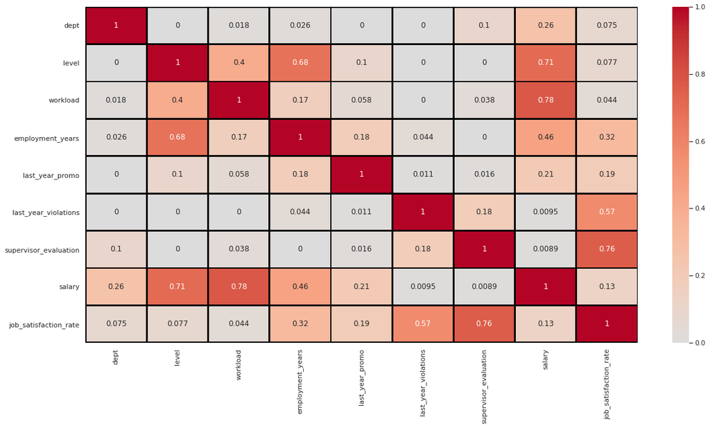

```python
plt.figure(figsize=(20, 10))
sns.heatmap(
    train.phik_matrix(interval_cols=['salary', 'job_satisfaction_rate']),
    cmap='coolwarm',
    center=0,
    annot=True,
    linewidths=2,
    linecolor='black',
)
```

Коэффициент корреляции не превышает 0.8, поэтому оставим все переменные.

### Моделирование

Сначала мы создадим стандартный pipeline с обработкой признаков, протестируем на нём одну модель без гиперпараметров. Потом протестируем разные методы обработки и предсказаний с помощью Grid Search, и выберем лучшую.

#### Подготовка данных

```python
X_train = train.drop(['job_satisfaction_rate'], axis=1)
X_train = X_train.sort_index()
y_train = train['job_satisfaction_rate']
y_train = y_train.sort_index()

X_test = X_test.sort_index()
y_test = y_test.sort_index()
```

Удостоверимся, что X_test и y_test соответствуют друг другу. Соединим их.

```python
test_df = X_test.merge(y_test, left_index=True, right_index=True)

X_test = test_df.drop(['job_satisfaction_rate'], axis=1)
y_test = test_df['job_satisfaction_rate']
```

Часть колонок стоит обработать one_hot энкодером, для некоторых подойдет ordinal_encoder

```python
ohe_cols = ['dept', 'last_year_promo', 'last_year_violations']
ord_cols = ['level', 'workload']
num_cols = ['salary', 'supervisor_evaluation', 'employment_years']
```

```python
ord_processor = Pipeline(
    # Обработка признаков с иерархией
    [
        (
            'simpleImputer_before_ord',
            SimpleImputer(missing_values=np.nan, strategy='most_frequent'),
        ),
        (
            'ord',
            OrdinalEncoder(
                categories=[
                    ['junior', 'middle', 'sinior'],
                    ['low', 'medium', 'high'],
                ],
                handle_unknown='use_encoded_value',
                unknown_value=np.nan,
            ),
        ),
        (
            'simpleImputer_after_ord',
            SimpleImputer(missing_values=np.nan, strategy='most_frequent'),
        ),
    ]
)
```

```python
ohe_processor = Pipeline(
    # Обработка признаков, где иерархия не важна
    [
        (
            'simpleImputer_ohe',
            SimpleImputer(missing_values=np.nan, strategy='most_frequent'),
        ),
        (
            'ohe',
            OneHotEncoder(
                drop='first', handle_unknown='ignore', sparse_output=False
            ),
        ),
    ]
)
```

```python
data_preprocessor = ColumnTransformer(
    # Пайплайн обработки
    [
        ('ohe', ohe_processor, ohe_cols),
        ('ord', ord_processor, ord_cols),
        ('num', StandardScaler(), num_cols),
    ],
    remainder='passthrough',
)
```

```python
pipe_final = Pipeline(
    # Финальный пайплайн
    [
        ('preprocessor', data_preprocessor),
        ('model', DecisionTreeRegressor(random_state=RANDOM_STATE)),
    ]
)
```

#### Поиск модели и обработки

Проверим разные модели с разными гиперпараметрами. Также попробуем разные обработчики числовых переменных.

```python
# Параметры логистической регрессии
lin_params = {}

lin_params['preprocessor__num'] = [
    StandardScaler(),
    MinMaxScaler(),
    RobustScaler(),
]

lin_params['model'] = [LinearRegression()]
```

```python
# Параметры для KNeighborsClassifier
knn_params = {}

knn_params['preprocessor__num'] = [
    StandardScaler(),
    MinMaxScaler(),
    RobustScaler(),
]

knn_params['model__n_neighbors'] = [2, 5, 10, 25, 50]
knn_params['model'] = [KNeighborsRegressor()]
```

```python
# Параметры для DecisionTreeClassifier
tree_params = {}

tree_params['preprocessor__num'] = [
    StandardScaler(),
    MinMaxScaler(),
    RobustScaler(),
]

tree_params['model__max_depth'] = [None]
tree_params['model__min_samples_leaf'] = range(5, 6)
tree_params['model__min_samples_split'] = range(20, 25)
tree_params['model__max_leaf_nodes'] = range(310, 333)
tree_params['model'] = [DecisionTreeRegressor(random_state=RANDOM_STATE)]
```

```python
# Параметры для SVC
svr_params = {}

svr_params['preprocessor__num'] = [
    StandardScaler(),
    MinMaxScaler(),
    RobustScaler(),
]

svr_params['model__C'] = [10**-2, 10**-1, 10**0, 10**1, 10**2]
svr_params['model'] = [SVR()]

params = [lin_params, knn_params, tree_params, svr_params]
```

```python
# Собственная метрика


def smape(true, pred):
    denominator = (np.abs(true) + np.abs(pred)) / 2
    diff = np.abs(true - pred) / denominator
    return np.mean(diff) * 100


smape_score = make_scorer(smape, greater_is_better=False)
```

```python
grid_reg = GridSearchCV(
    pipe_final, params, cv=5, n_jobs=-1, scoring=smape_score
)
```

```python
grid_reg.fit(X_train, y_train)
```

```
GridSearchCV(cv=5,
             estimator=Pipeline(steps=[('preprocessor',
                                        ColumnTransformer(remainder='passthrough',
                                                          transformers=[('ohe',
                                                                         Pipeline(steps=[('simpleImputer_ohe',
                                                                                          SimpleImputer(strategy='most_frequent')),
                                                                                         ('ohe',
                                                                                          OneHotEncoder(drop='first',
                                                                                                        handle_unknown='ignore',
                                                                                                        sparse_output=False))]),
                                                                         ['dept',
                                                                          'last_year_promo',
                                                                          'last_year_violations']),
                                                                        ('ord',
                                                                         Pipeline(...
                          'model__max_leaf_nodes': range(310, 333),
                          'model__min_samples_leaf': range(5, 6),
                          'model__min_samples_split': range(20, 25),
                          'preprocessor__num': [StandardScaler(),
                                                MinMaxScaler(),
                                                RobustScaler()]},
                         {'model': [SVR()], 'model__C': [0.01, 0.1, 1, 10, 100],
                          'preprocessor__num': [StandardScaler(),
                                                MinMaxScaler(),
                                                RobustScaler()]}],
             scoring=make_scorer(smape, greater_is_better=False))
```

#### Лучшая модель

```python
# Лучший регрессор
grid_reg.best_estimator_
```

```
Pipeline(steps=[('preprocessor',
                 ColumnTransformer(remainder='passthrough',
                                   transformers=[('ohe',
                                                  Pipeline(steps=[('simpleImputer_ohe',
                                                                   SimpleImputer(strategy='most_frequent')),
                                                                  ('ohe',
                                                                   OneHotEncoder(drop='first',
                                                                                 handle_unknown='ignore',
                                                                                 sparse_output=False))]),
                                                  ['dept', 'last_year_promo',
                                                   'last_year_violations']),
                                                 ('ord',
                                                  Pipeline(steps=[('simpleImputer_befor...
                                                                   SimpleImputer(strategy='most_frequent')),
                                                                  ('ord',
                                                                   OrdinalEncoder(categories=[['junior',
                                                                                               'middle',
                                                                                               'sinior'],
                                                                                              ['low',
                                                                                               'medium',
                                                                                               'high']],
                                                                                  handle_unknown='use_encoded_value',
                                                                                  unknown_value=nan)),
                                                                  ('simpleImputer_after_ord',
                                                                   SimpleImputer(strategy='most_frequent'))]),
                                                  ['level', 'workload']),
                                                 ('num', StandardScaler(),
                                                  ['salary',
                                                   'supervisor_evaluation',
                                                   'employment_years'])])),
                ('model', SVR(C=10))])
```

```python
# Метрика на кросс-валидации
grid_reg.best_score_ * -1
```

```
14.744530765253975
```

Зафиксируем лучшую модель. Она нам ещё пригодится.

```python
best_regressor = grid_reg.best_estimator_
```

```python
y_pred = best_regressor.predict(X_test)
```

```python
smape(y_test, y_pred)
```

```
13.551677608389545
```

Лучше всего сработал метод опорных веторов с параметром C = 10.

Сравним работу модели с `DummyRegressor`, чтобы убедиться, что в ней есть смысл.

```python
dummy_regressor = DummyRegressor(strategy='median')
dummy_regressor.fit(X_train, y_train)
dummy_regressor_pred = dummy_regressor.predict(X_test)
smape(y_test, dummy_regressor_pred)
```

```
37.77281981888386
```

Модель показала себя сильно лучше.

#### Сравнение разных моделей

```python
results_df_reg = pd.DataFrame(grid_reg.cv_results_)
results_df_reg = results_df_reg.sort_values(by=["rank_test_score"])
results_df_reg = results_df_reg.set_index(
    results_df_reg["params"].apply(
        lambda x: "_".join(str(val) for val in x.values())
    )
).rename_axis("kernel")
results_df_reg['mean_test_score'] *= -1
results_df_reg[
    ["params", "rank_test_score", "mean_test_score", "std_test_score"]
].head()
```

| kernel | params | rank_test_score | mean_test_score | std_test_score |
| --- | --- | --- | --- | --- |
| SVR()_10_StandardScaler() | {'model': SVR(), 'model__C': 10, 'preprocessor... | 1 | 14.744531 | 0.419438 |
| SVR()_1_StandardScaler() | {'model': SVR(), 'model__C': 1, 'preprocessor_... | 2 | 14.782383 | 0.381073 |
| SVR()_10_RobustScaler() | {'model': SVR(), 'model__C': 10, 'preprocessor... | 3 | 14.911387 | 0.263683 |
| SVR()_1_RobustScaler() | {'model': SVR(), 'model__C': 1, 'preprocessor_... | 4 | 14.985796 | 0.358129 |
| DecisionTreeRegressor(random_state=42)_None_310_5_23_MinMaxScaler() | {'model': DecisionTreeRegressor(random_state=4... | 5 | 15.567033 | 0.766446 |

## Предсказание увольнения

### Загрузка данных

```python
train_q = pd.read_csv('/datasets/train_quit.csv').set_index('id')
X_test_q = pd.read_csv('/datasets/test_features.csv').set_index('id')
y_test_q = pd.read_csv('/datasets/test_target_quit.csv').set_index('id')
```

### Исследовательский анализ данных

#### Общий обзор

```python
for df in [train_q, X_test_q, y_test_q]:
    df = transform_columns_values(df)
```

```
<class 'pandas.core.frame.DataFrame'>
Int64Index: 4000 entries, 723290 to 853842
Data columns (total 9 columns):
 #   Column                 Non-Null Count  Dtype
---  ------                 --------------  -----
 0   dept                   4000 non-null   object
 1   level                  4000 non-null   object
 2   workload               4000 non-null   object
 3   employment_years       4000 non-null   int64
 4   last_year_promo        4000 non-null   object
 5   last_year_violations   4000 non-null   object
 6   supervisor_evaluation  4000 non-null   int64
 7   salary                 4000 non-null   int64
 8   quit                   4000 non-null   object
dtypes: int64(3), object(6)
memory usage: 312.5+ KB
```

```
None
```

|  | employment_years | supervisor_evaluation | salary |
| --- | --- | --- | --- |
| count | 4000.000000 | 4000.000000 | 4000.000000 |
| mean | 3.701500 | 3.474750 | 33805.800000 |
| std | 2.541852 | 1.004049 | 15152.415163 |
| min | 1.000000 | 1.000000 | 12000.000000 |
| 25% | 2.000000 | 3.000000 | 22800.000000 |
| 50% | 3.000000 | 4.000000 | 30000.000000 |
| 75% | 6.000000 | 4.000000 | 43200.000000 |
| max | 10.000000 | 5.000000 | 96000.000000 |

| id | dept | level | workload | employment_years | last_year_promo | last_year_violations | supervisor_evaluation | salary | quit |
| --- | --- | --- | --- | --- | --- | --- | --- | --- | --- |
| 723290 | sales | middle | high | 2 | no | no | 4 | 54000 | no |
| 814010 | sales | junior | medium | 2 | no | no | 4 | 27600 | no |
| 155091 | purchasing | middle | medium | 5 | no | no | 1 | 37200 | no |
| 257132 | sales | junior | medium | 2 | no | yes | 3 | 24000 | yes |
| 910140 | marketing | junior | medium | 2 | no | no | 5 | 25200 | no |

```
Явных дублей: 1413


Пропущенных значений:
```

|  | 0 |
| --- | --- |
| dept | 0.000000 |
| level | 0.000000 |
| workload | 0.000000 |
| employment_years | 0.000000 |
| last_year_promo | 0.000000 |
| last_year_violations | 0.000000 |
| supervisor_evaluation | 0.000000 |
| salary | 0.000000 |
| quit | 0.000000 |

```
<class 'pandas.core.frame.DataFrame'>
Int64Index: 2000 entries, 485046 to 771859
Data columns (total 8 columns):
 #   Column                 Non-Null Count  Dtype
---  ------                 --------------  -----
 0   dept                   1998 non-null   object
 1   level                  1999 non-null   object
 2   workload               2000 non-null   object
 3   employment_years       2000 non-null   int64
 4   last_year_promo        2000 non-null   object
 5   last_year_violations   2000 non-null   object
 6   supervisor_evaluation  2000 non-null   int64
 7   salary                 2000 non-null   int64
dtypes: int64(3), object(5)
memory usage: 140.6+ KB
```

```
None
```

|  | employment_years | supervisor_evaluation | salary |
| --- | --- | --- | --- |
| count | 2000.000000 | 2000.000000 | 2000.000000 |
| mean | 3.666500 | 3.526500 | 34066.800000 |
| std | 2.537222 | 0.996892 | 15398.436729 |
| min | 1.000000 | 1.000000 | 12000.000000 |
| 25% | 1.000000 | 3.000000 | 22800.000000 |
| 50% | 3.000000 | 4.000000 | 30000.000000 |
| 75% | 6.000000 | 4.000000 | 43200.000000 |
| max | 10.000000 | 5.000000 | 96000.000000 |

| id | dept | level | workload | employment_years | last_year_promo | last_year_violations | supervisor_evaluation | salary |
| --- | --- | --- | --- | --- | --- | --- | --- | --- |
| 485046 | marketing | junior | medium | 2 | no | no | 5 | 28800 |
| 686555 | hr | junior | medium | 1 | no | no | 4 | 30000 |
| 467458 | sales | middle | low | 5 | no | no | 4 | 19200 |
| 418655 | sales | middle | low | 6 | no | no | 4 | 19200 |
| 789145 | hr | middle | medium | 5 | no | no | 5 | 40800 |

```
Явных дублей: 557


Пропущенных значений:
```

|  | 0 |
| --- | --- |
| dept | 0.100000 |
| level | 0.000000 |
| workload | 0.000000 |
| employment_years | 0.000000 |
| last_year_promo | 0.000000 |
| last_year_violations | 0.000000 |
| supervisor_evaluation | 0.000000 |
| salary | 0.000000 |

```
<class 'pandas.core.frame.DataFrame'>
Int64Index: 2000 entries, 999029 to 460332
Data columns (total 1 columns):
 #   Column  Non-Null Count  Dtype
---  ------  --------------  -----
 0   quit    2000 non-null   object
dtypes: object(1)
memory usage: 31.2+ KB
```

```
None
```

|  | quit |
| --- | --- |
| count | 2000 |
| unique | 2 |
| top | no |
| freq | 1436 |

| id | quit |
| --- | --- |
| 999029 | yes |
| 372846 | no |
| 726767 | no |
| 490105 | no |
| 416898 | yes |

```
Явных дублей: 1998


Пропущенных значений:
```

|  | 0 |
| --- | --- |
| quit | 0.000000 |

Пропущенные значения мы обработаем на этапе подготовки данных.

#### Выбросы

Проверим непрерывные переменные на предмет выбросов с помощью вычисления z-значения.

```python
# Аномальные зарплаты в тренировочной выборке
anomal_salary = train_q[np.abs(stats.zscore(train_q['salary'])) >= 3]
print(f'''Аномальных зарплат: {len(anomal_salary)}''')
anomal_salary.head()
```

```
Аномальных зарплат: 31
```

| id | dept | level | workload | employment_years | last_year_promo | last_year_violations | supervisor_evaluation | salary | quit |
| --- | --- | --- | --- | --- | --- | --- | --- | --- | --- |
| 113657 | technology | sinior | high | 5 | yes | no | 3 | 82800 | no |
| 208223 | technology | sinior | high | 7 | no | no | 3 | 94800 | no |
| 694599 | technology | sinior | high | 1 | no | no | 4 | 96000 | no |
| 638931 | technology | sinior | high | 10 | no | no | 4 | 88800 | no |
| 740852 | technology | sinior | high | 8 | no | no | 4 | 96000 | no |

```python
anomal_salary[['level', 'dept']].value_counts()
```

```
level   dept
sinior  technology    19
        marketing      7
        hr             3
        purchasing     1
        sales          1
dtype: int64
```

```python
# Аномальные зарплаты в тестовой выборке
anomal_salary = X_test_q[np.abs(stats.zscore(X_test_q['salary'])) >= 3]
print(f'''Аномальных зарплат: {len(anomal_salary)}''')
anomal_salary.head()
```

```
Аномальных зарплат: 23
```

| id | dept | level | workload | employment_years | last_year_promo | last_year_violations | supervisor_evaluation | salary |
| --- | --- | --- | --- | --- | --- | --- | --- | --- |
| 540148 | hr | sinior | high | 4 | no | no | 5 | 81600 |
| 270400 | technology | sinior | high | 2 | no | no | 4 | 94800 |
| 719982 | marketing | sinior | high | 9 | no | no | 5 | 82800 |
| 950627 | technology | sinior | high | 6 | no | no | 5 | 80400 |
| 145965 | technology | sinior | high | 1 | no | no | 4 | 87600 |

```python
anomal_salary[['level', 'dept']].value_counts()
```

```
level   dept
sinior  technology    16
        hr             3
        marketing      2
        purchasing     1
        sales          1
dtype: int64
```

Нетипичные зарплаты имеют старшие специалисты всех отделов. Их не очень много по сравнению с младшими и средними, поэтому считаем, что это нормально. В тестовой выборке они тоже присутствуют, важно уметь их предсказывать.

#### Неявные дубли

```python
train_q[train_q.duplicated(keep=False)].sort_values(
    ['dept', 'level', 'employment_years']
).tail(4)
```

| id | dept | level | workload | employment_years | last_year_promo | last_year_violations | supervisor_evaluation | salary | quit |
| --- | --- | --- | --- | --- | --- | --- | --- | --- | --- |
| 555944 | technology | sinior | medium | 6 | no | yes | 3 | 62400 | no |
| 897944 | technology | sinior | medium | 6 | no | yes | 3 | 62400 | no |
| 327415 | technology | sinior | medium | 8 | no | no | 4 | 56400 | no |
| 918828 | technology | sinior | medium | 8 | no | no | 4 | 56400 | no |

После выноса `id` в индекс, появились дубликаты, которые могут затруднить обучение модели. Избавимся от них.

```python
train_q = train_q.drop_duplicates()
```

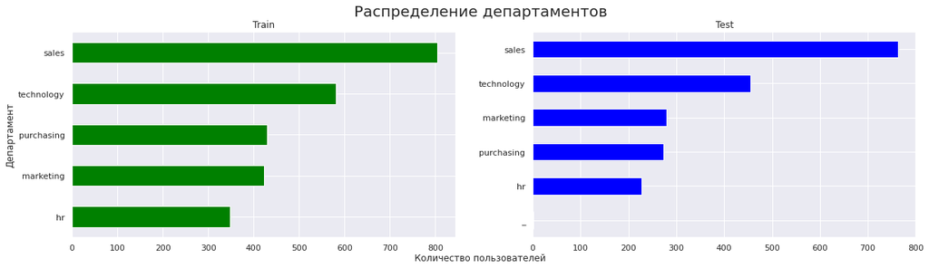

```python
plot_train_test(
    train_q, X_test_q, 'dept', 'Распределение департаментов', 'Департамент'
)
```

Видно, что структура в целом очень похожа. В тестовом датасете есть ошибочные записи, в них отдел указан как '_'. Заполним их пустыми значениями.

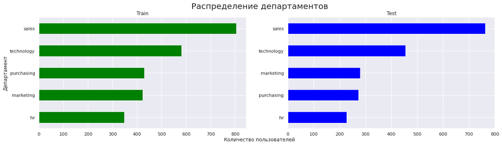

```python
X_test_q['dept'] = X_test_q['dept'].replace('_', np.nan)
plot_train_test(
    train_q, X_test_q, 'dept', 'Распределение департаментов', 'Департамент'
)
```

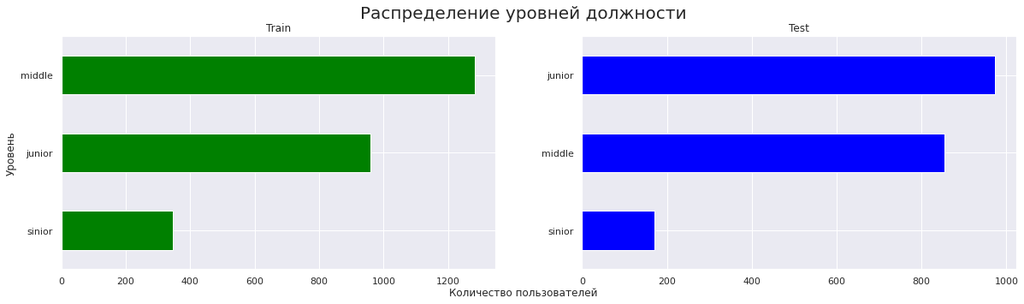

```python
plot_train_test(
    train_q, X_test_q, 'level', 'Распределение уровней должности', 'Уровень'
)
```

В тренировочном датасете больше позиций специалистов среднего уровня. В тестовом - больше младших.

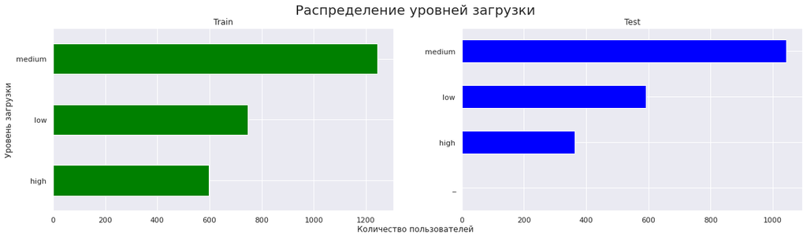

```python
plot_train_test(
    train_q,
    X_test_q,
    'workload',
    'Распределение уровней загрузки',
    'Уровень загрузки',
)
```

Снова видно записи с ошибкой в тестовой выборке. Заполним пустыми значениями.

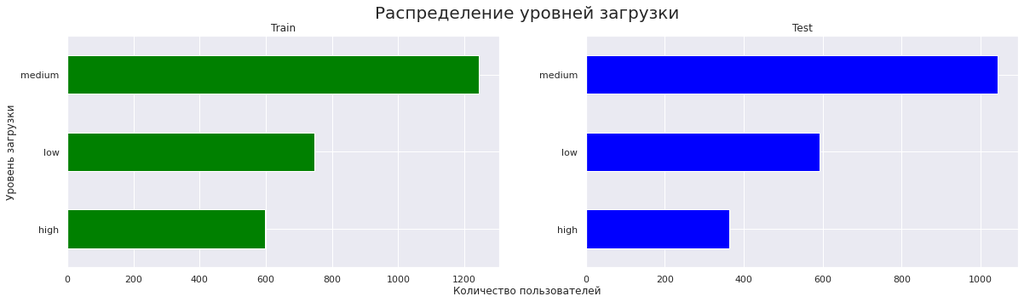

```python
X_test_q['workload'] = X_test_q['workload'].replace('_', np.nan)
plot_train_test(
    train_q,
    X_test_q,
    'workload',
    'Распределение уровней загрузки',
    'Уровень загрузки',
)
```

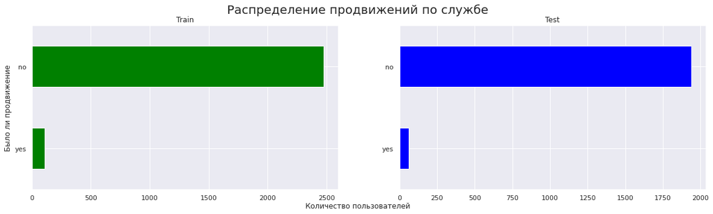

```python
plot_train_test(
    train_q,
    X_test_q,
    'last_year_promo',
    'Распределение продвижений по службе',
    'Было ли продвижение',
)
```

Ситуация как в предыдущем датасете. Не так много людей получают продвижение.

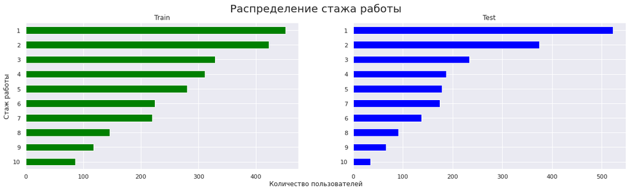

```python
plot_train_test(
    train_q,
    X_test_q,
    'employment_years',
    'Распределение стажа работы',
    'Стаж работы',
)
```

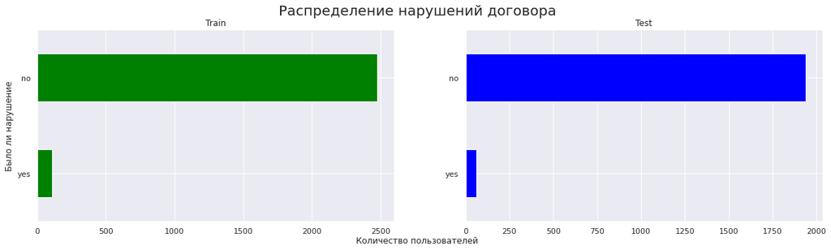

```python
plot_train_test(
    train_q,
    X_test_q,
    'last_year_promo',
    'Распределение нарушений договора',
    'Было ли нарушение',
)
```

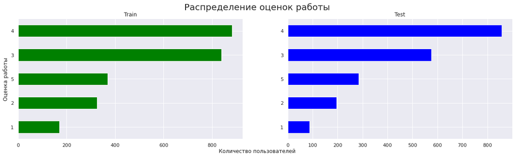

```python
plot_train_test(
    train_q,
    X_test_q,
    'supervisor_evaluation',
    'Распределение оценок работы',
    'Оценка работы',
)
```

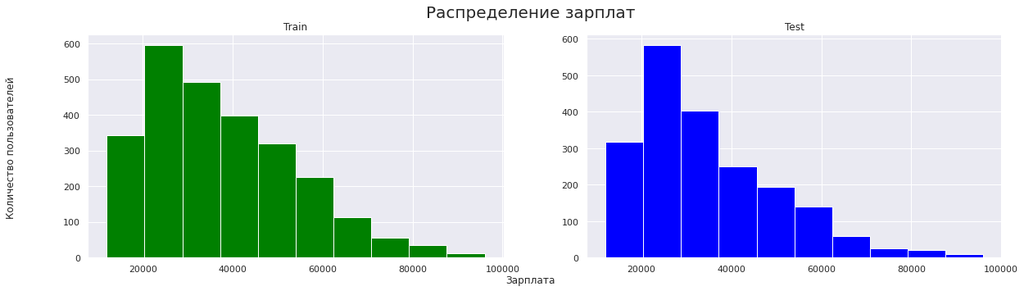

```python
f, (ax1, ax2) = plt.subplots(1, 2, figsize=(20, 5))
f.suptitle('Распределение зарплат', fontsize=20)

f.text(0.5, 0.04, 'Зарплата', ha='center')
f.text(
    0.06,
    0.5,
    'Количество пользователей',
    ha='center',
    va='center',
    rotation='vertical',
)

train_q['salary'].hist(figsize=(20, 5), color='green', ax=ax1)
ax1.set_title('Train')

X_test_q['salary'].hist(figsize=(20, 5), color='blue', ax=ax2)
ax2.set_title('Test')

plt.show()
```

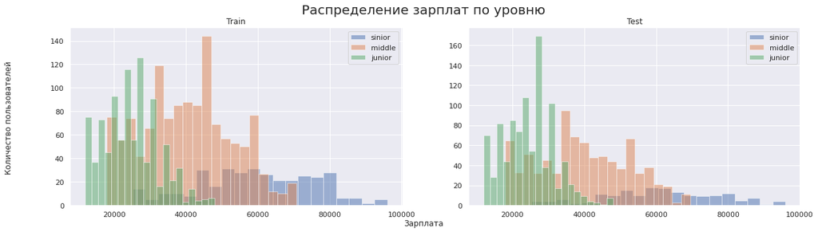

```python
f, (ax1, ax2) = plt.subplots(1, 2, figsize=(20, 5))
f.suptitle('Распределение зарплат по уровню', fontsize=20)

f.text(0.5, 0.04, 'Зарплата', ha='center')
f.text(
    0.06,
    0.5,
    'Количество пользователей',
    ha='center',
    va='center',
    rotation='vertical',
)

ax1.hist(
    train_q.query('level == "sinior"')['salary'],
    bins=20,
    alpha=0.5,
    label='sinior',
)
ax1.hist(
    train_q.query('level == "middle"')['salary'],
    bins=20,
    alpha=0.5,
    label='middle',
)
ax1.hist(
    train_q.query('level == "junior"')['salary'],
    bins=20,
    alpha=0.5,
    label='junior',
)
ax1.set_title('Train')
ax1.legend()

ax2.hist(
    X_test_q.query('level == "sinior"')['salary'],
    bins=20,
    alpha=0.5,
    label='sinior',
)
ax2.hist(
    X_test_q.query('level == "middle"')['salary'],
    bins=20,
    alpha=0.5,
    label='middle',
)
ax2.hist(
    X_test_q.query('level == "junior"')['salary'],
    bins=20,
    alpha=0.5,
    label='junior',
)
ax2.set_title('Test')
ax2.legend()

plt.show()
```

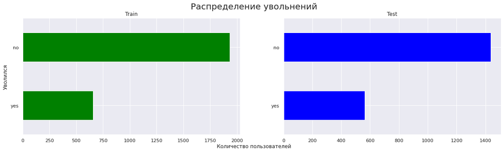

```python
plot_train_test(
    train_q, y_test_q, 'quit', 'Распределение увольнений', 'Уволился'
)
```

Выборки в целом похожи друг на друга. Несколько отличаются только распределения грейдов.

### Корреляционный анализ

Мультиколинеарность может затруднить работу регрессионных моделей. Проверим, нет ли её.

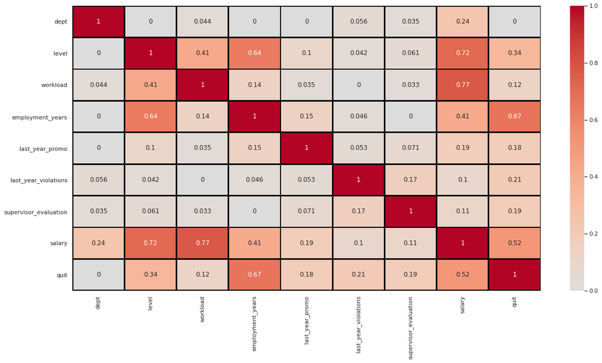

```python
plt.figure(figsize=(20, 10))
sns.heatmap(
    train_q.phik_matrix(interval_cols=['salary']),
    cmap='coolwarm',
    center=0,
    annot=True,
    linewidths=2,
    linecolor='black',
)
```

Наблюдается высокая корреляция уровня загрузки и зарплаты. Она не превышает критического значения. Также для задач классификации мультиколинеарность не так уж и важна. Оставляем все переменные.

### Портрет уволившегося сотрудника

Посмотрим на распределения разных параметров у оставшихся и уволившихся сотрудников.

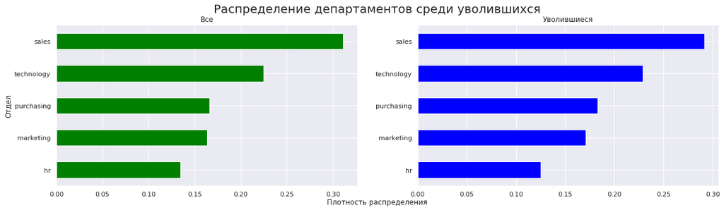

```python
plot_train_test(
    train_q,
    train_q.query('quit == "yes"'),
    'dept',
    'Распределение департаментов среди уволившихся',
    'Отдел',
    True,
    'Все',
    'Уволившиеся',
    'Плотность распределения',
)
```

Количество уволившихся пользователей повторяет контур количества оставшихся.

```python
pd.DataFrame(
    (
        train_q.query('quit == "yes"')['dept'].value_counts(normalize=True)
        - train_q['dept'].value_counts(normalize=True)
    )
).style.format(formatter={'dept': "{0:.0%}"})
```

|  | dept |
| --- | --- |
| sales | -2% |
| technology | 0% |
| purchasing | 2% |
| marketing | 1% |
| hr | -1% |

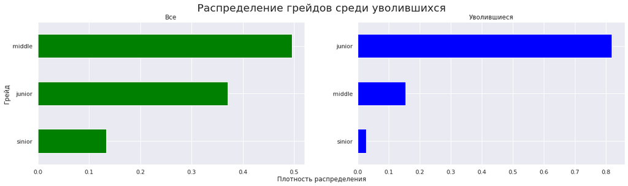

```python
plot_train_test(
    train_q,
    train_q.query('quit == "yes"'),
    'level',
    'Распределение грейдов среди уволившихся',
    'Грейд',
    True,
    'Все',
    'Уволившиеся',
    'Плотность распределения',
)
```

```python
pd.DataFrame(
    (
        train_q.query('quit == "yes"')['level'].value_counts(normalize=True)
        - train_q['level'].value_counts(normalize=True)
    )
).style.format(formatter={'dept': "{0:.0%}"})
```

|  | level |
| --- | --- |
| junior | 0.449534 |
| middle | -0.341356 |
| sinior | -0.108178 |

Сильно чаще увольняются младшие специалисты.

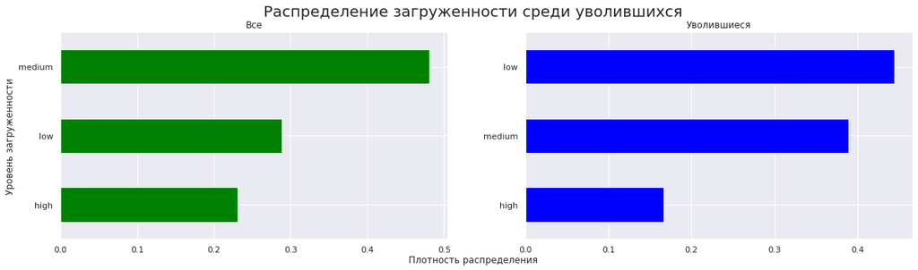

```python
plot_train_test(
    train_q,
    train_q.query('quit == "yes"'),
    'workload',
    'Распределение загруженности среди уволившихся',
    'Уровень загруженности',
    True,
    'Все',
    'Уволившиеся',
    'Плотность распределения',
)
```

```python
pd.DataFrame(
    (
        train_q.query('quit == "yes"')['workload'].value_counts(normalize=True)
        - train_q['workload'].value_counts(normalize=True)
    )
).style.format(formatter={'workload': "{0:.0%}"})
```

|  | workload |
| --- | --- |
| high | -6% |
| low | 16% |
| medium | -9% |

Меньше всего увольняются сотрудники со средней загруженностью, а больше всего - с низкой. Можно предположить, что незагруженные сотрудники ощущают свою ненужность компании и не хотят попусту тратить время. Им нечего будет написать в резюме о завершенных проектах, они имеют меньше шансов продвинуться по службе. Возможно, поэтому ищут другое место.

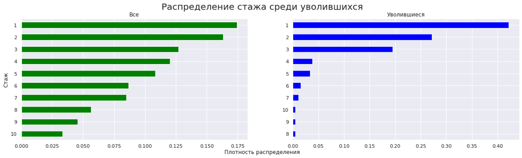

```python
plot_train_test(
    train_q,
    train_q.query('quit == "yes"'),
    'employment_years',
    'Распределение стажа среди уволившихся',
    'Стаж',
    True,
    'Все',
    'Уволившиеся',
    'Плотность распределения',
)
```

```python
pd.DataFrame(
    (
        train_q.query('quit == "yes"')['employment_years'].value_counts(
            normalize=True
        )
        - train_q['employment_years'].value_counts(normalize=True)
    )
).style.format(formatter={'employment_years': "{0:.0%}"})
```

|  | employment_years |
| --- | --- |
| 1 | 25% |
| 2 | 11% |
| 3 | 7% |
| 4 | -8% |
| 5 | -7% |
| 6 | -7% |
| 7 | -7% |
| 8 | -5% |
| 9 | -4% |
| 10 | -3% |

Основная масса увольнений приходится на первый год работы. После трёх лет работы количество уволившихся стремительно падает.

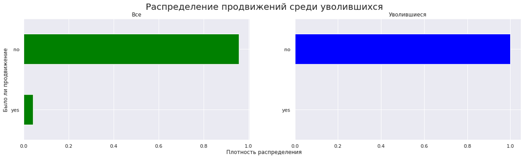

```python
plot_train_test(
    train_q,
    train_q.query('quit == "yes"'),
    'last_year_promo',
    'Распределение продвижений среди уволившихся',
    'Было ли продвижение',
    True,
    'Все',
    'Уволившиеся',
    'Плотность распределения',
)
```